# Factors affecting number of bike rentals, trip duration and the effect of COVID-19 pandemic on Citi Bike

## by Nour Emam

## Investigation Overview

Citi Bike is New York's offical bike sharing system. It consists of a fleet of bikes that are locked into docking stations spread out across the city. The goal of this investigation was to understand the profiles of different users of the bike rental platform, what could be the most common characteristics that would effect the duration of a single bike trip and what was the effect of COVID-19 on the usage of the bike rental platform.

## Dataset Overview

The dataset was obtained via Bikeshare. It consists of just over 4 million records and 11 variables. Each record represents one trip and the data is monthly for the years 2019 and 2020. The variables that describe a trip include trip duration, start and end station, start and end date as well as some user specific data such as age, user type (can be a customer or a subscriber) and gender. 40,048 records (only around 1% of the data) were excluded from the analysis after the initial investigation of distributions due to the extremes in trip duration recorded which was causing inconsistencies.

## Age Distribution

Citi Bike is most popular among users aged between 25-29 with around 750,000 trips followed by age groups 30-34. Third most common age group is 50-54 with just under 600,000 trips recorded across both years 2019 and 2020.

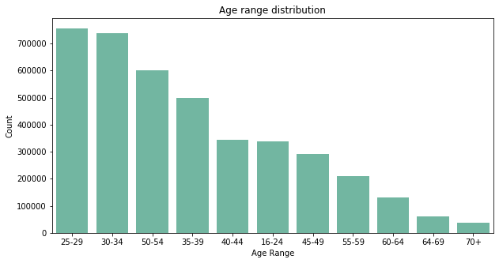

```python
#setting base and secondary colours to be used across the graphs
base_color = sb.color_palette('Set2')[0]
secondary_color = sb.color_palette('Set2')[1]

#plot distribution of age ranges

plt.figure(figsize = [10, 5])

range_order = df_main.agerange.value_counts().index
sb.countplot(data=df_main, x='agerange', color=base_color, order=range_order)
plt.xlabel('Age Range')
plt.ylabel('Count')
plt.title('Age range distribution');
```

## Gender

According to the dataset, around 65% of bike renters are Males. 26% of renters are Females and the remaining around 9% are 'Unknown'.

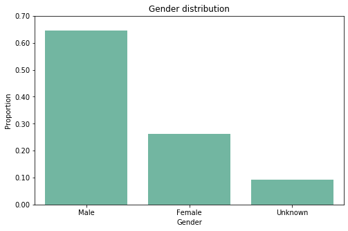

```python
gender_overall = df_main['gender'].value_counts().sum()
gender_counts = df_main['gender'].value_counts()
gender_prop = gender_counts / gender_overall
tick_props = np.arange(0, max(gender_prop)+0.1, 0.1)
tick_names = ['{:0.2f}'.format(v) for v in tick_props]

plt.figure(figsize = [10, 5])

sb.countplot(data=df_main, x='gender', color=base_color);
# Change the tick locations and labels
plt.yticks(gender_overall * tick_props, tick_names)
plt.ylabel('Proportion')
plt.xlabel('Gender')
plt.title('Gender distribution');
```

## User Types

As shown in the pie chart, 81.47% of the users are Subscribers with an annual pass to use the platform and the remaining 18.53% are Customers who have the option to buy either a 24-hour or 3-day pass.

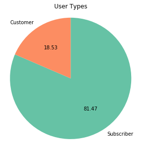

```python
# User type
plt.figure(figsize = [10, 5])

usertype_counts = df_main['usertype'].value_counts()
colors = [base_color, secondary_color]
plt.pie(usertype_counts, labels = usertype_counts.index, startangle = 90, counterclock = False, colors=colors, autopct='%.2f');
plt.axis('square')
plt.title('User Types');
```

## Trips per Month

As expected, number of trips during the colder months is much lower. It begins to rise as weather becomes warmer around May and keeps increasing reaching the highest number in September then falls back in October, November and December.

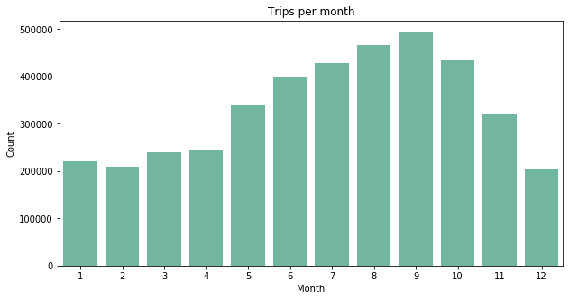

```python
plt.figure(figsize = [10, 5])

sb.countplot(data=df_main, x='month', color=base_color)
plt.ylabel('Count')
plt.xlabel('Month')
plt.title('Trips per month');
```

## Duration Distribution

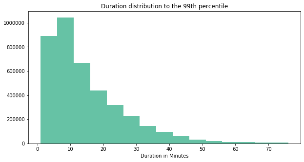

```python
#plot duration in minutes
plt.figure(figsize = [10, 5])

bins = np.arange(df_main['tripdurationmins'].min(), (duration_percentile['99%'] / 60)+5, 5)
plt.hist(data = df_main, x = 'tripdurationmins', bins=bins, color=base_color)
plt.title('Duration distribution to the 99th percentile')
plt.xlabel('Duration in Minutes');
```

## Age Range vs Duration

When plotting the range of duration across different age ranges it is clearly visible that users aged between 50-54 have the highest range of duration and even the highest maximum duration of a bike ride reaching around 50 minutes. This group is followed by age range 16-24.

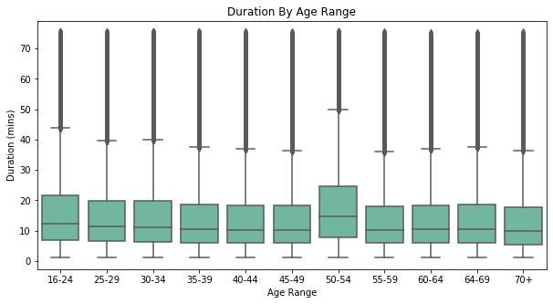

```python
#age range vs duration in minutes
plt.figure(figsize = [10, 5])

sb.boxplot(data=durations_less_than_99_percentile, x='agerange', y='tripdurationmins', color=base_color)
plt.xlabel('Age Range')
plt.ylabel('Duration (mins)')
plt.title('Duration By Age Range');
```

## Gender vs Duration

Most male users rent the bikes for shorter durations (10 mins on average) compared to female bike riders (average slightly higher), the graph shows that females and mostly 'unknown' are distributed across higher durations. With 'unknown' having the highest mean duration of around 20 minutes.

## User Type vs Duration

As for user types, most subscribers go for shorter trips since they are probably using Citi Bike more often throughout their day-to-day to get to work or school. While customers on the other hand tend to rent the bikes for longer durations with almost double the average duration of subscribers, this shows that customers might be tourists or users not premanently staying in New York so could be using the bikes for longer durations to explore the city.

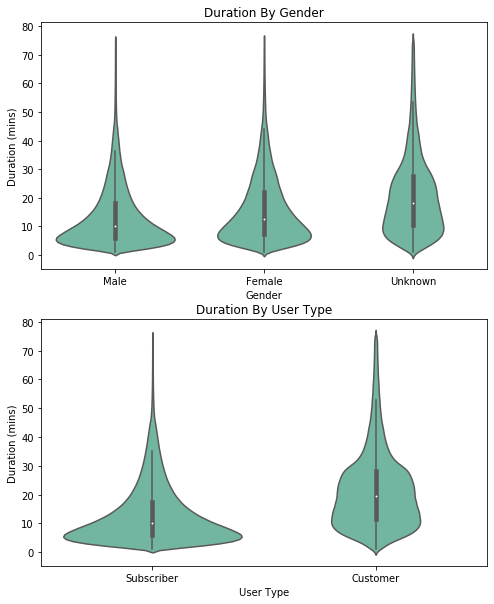

```python
plt.figure(figsize = [8, 10])

#gender and duration
plt.subplot(2, 1, 1)
sb.violinplot(data=durations_less_than_99_percentile, x='gender', y='tripdurationmins', color=base_color)
plt.xlabel('Gender')
plt.ylabel('Duration (mins)')
plt.title('Duration By Gender');

#user type and duration
plt.subplot(2, 1, 2)
sb.violinplot(data=durations_less_than_99_percentile, x='usertype', y='tripdurationmins', color=base_color)
plt.xlabel('User Type')
plt.ylabel('Duration (mins)')
plt.title('Duration By User Type');
```

## Average Duration per Month

Average trip duration reaches the highest peak in May and June.

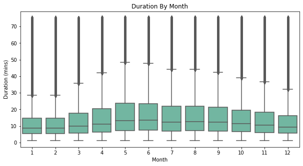

```python
#month and duration
plt.figure(figsize = [10, 5])

sb.boxplot(data=durations_less_than_99_percentile, x='month', y='tripdurationmins', color=base_color)
plt.xlabel('Month')
plt.ylabel('Duration (mins)')
plt.title('Duration By Month');
```

## Number of Trips by Month and User Type and the Effect on Average Trip Duration 1/2

As suspected, the number of customers start to increase around May and June - we've observed before that customers generally have higher average trip durations than subscribers which indicates a relationship between month and user type. Even though the number of customers continue to increase, we can see that in September, the month with the highest number of trips, it is also the highest count of subscribers therefore this takes down the average trip duration.

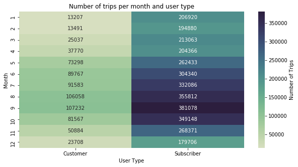

```python
#count trips by usertype and month to investigate the higher duration average in May and June.

trips_user_month = durations_less_than_99_percentile.groupby(['month', 'usertype'])['bikeid'].count()
trips_user_month = trips_user_month.reset_index(name='trips')
trips_user_month = trips_user_month.pivot(index = 'month', columns = 'usertype', values = 'trips')
trips_user_month

plt.figure(figsize = [10, 5])
heatmap_color = sb.cubehelix_palette(start=.5, rot=-.75, as_cmap=True)

sb.heatmap(trips_user_month, annot = True, fmt = '.0f', cmap=heatmap_color,
           cbar_kws = {'label' : 'Number of Trips'})
plt.title('Number of trips per month and user type')
plt.xlabel('User Type')
plt.ylabel('Month');
```

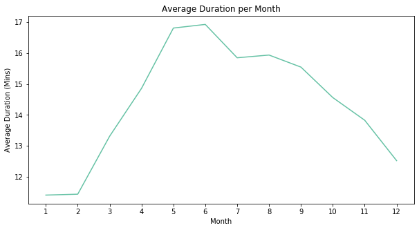

```python
#average duration per month plotted as a line graph to show the change across each month

average_duration_month = durations_less_than_99_percentile.groupby('month')['tripdurationmins'].mean()
average_duration_month = average_duration_month.reset_index(name='meandurationmins')

plt.figure(figsize = [10, 5])

plt.errorbar(data=average_duration_month, x='month', y='meandurationmins', color=base_color)
plt.xticks(average_duration_month.month)
plt.ylabel('Average Duration (Mins)')
plt.xlabel('Month')
plt.title('Average Duration per Month');
```

## Number of Trips by Month and User Type and the Effect on Average Trip Duration 2/2

This graph shows the change in average duration per user type throughout the year. As we can see the customers have almost double the average trip duration compared to subscribers. The customers average trip duration reaches the peak of 24 minutes in May compared to around 15 minutes for subscribers. This graph truly differentiates that the user type is a good indicator or predictor of the trip duration.

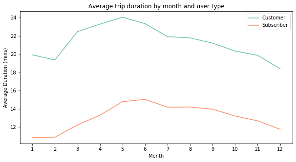

```python
#average duration across the user types per month
average_duration_month_user = durations_less_than_99_percentile.groupby(['month', 'usertype'])['tripdurationmins'].mean()
average_duration_month_user = average_duration_month_user.reset_index(name='meandurationmins')
average_duration_month_user = average_duration_month_user.pivot(index = 'month', columns = 'usertype', values = 'meandurationmins')

plt.figure(figsize = [10, 5])

plt.plot(average_duration_month_user['Customer'], label="Customer", color = base_color)
plt.plot(average_duration_month_user['Subscriber'], label="Subscriber", color = secondary_color)
plt.xticks(average_duration_month_user.index)
plt.ylabel('Average Duration (mins)')
plt.xlabel('Month')
plt.title('Average trip duration by month and user type')
plt.legend()
plt.show();
```

## Number of Trips by Age Range and User Type and the Effect on Average Trip Duration 1/2

We can observe in the visualization between age range and user type that most users aged 50-54 are customers. Across all the other age groups the number of subscribers is greater than the number of customers.

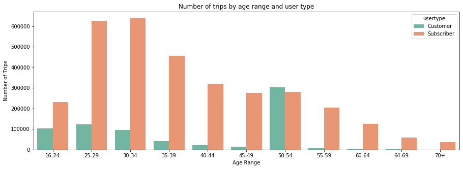

```python
#count trips by age range and user type
trips_age_usertype = durations_less_than_99_percentile.groupby(['usertype', 'agerange'])['bikeid'].count()
trips_age_usertype = trips_age_usertype.reset_index(name='trips')
trips_age_usertype

plt.figure(figsize = [15, 5])

sb.barplot(data = trips_age_usertype, x = 'agerange', y = 'trips',  hue = 'usertype', palette = 'Set2')
plt.title('Number of trips by age range and user type')
plt.xlabel('Age Range')
plt.ylabel('Number of Trips');
```

## Number of Trips by Age Range and User Type and the Effect on Average Trip Duration 2/2

Even with the very low number of customers in that age range, it seems that customers in the 70+ age group have the highest average trip duration! Keeping in mind that customers data might be less accurate in terms of demographics, there sure is a trend that shows that older aged customers enjoy riding the bikes for longer durations.

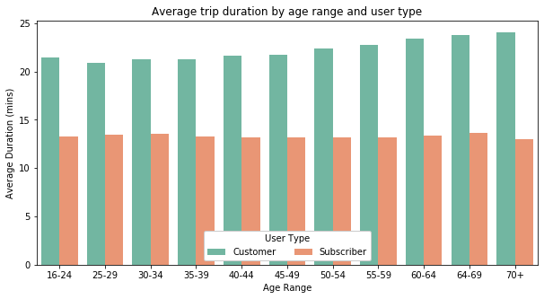

```python
#average trip duration by age range and user type
average_duration_age_user = durations_less_than_99_percentile.groupby(['agerange', 'usertype'])['tripdurationmins'].mean()
average_duration_age_user = average_duration_age_user.reset_index(name='meandurationmins')

plt.figure(figsize = [10, 5])

ax = sb.barplot(data = average_duration_age_user, x = 'agerange', y = 'meandurationmins', hue = 'usertype', palette = 'Set2')
ax.legend(loc = 8, ncol = 3, framealpha = 1, title = 'User Type')
plt.xlabel('Age Range')
plt.ylabel('Average Duration (mins)')
plt.title('Average trip duration by age range and user type');
```

## Number of Trips by Age Range and Gender and the Effect on Average Trip Duration 1/2

When it comes to the distribution of genders we've seen earlier that around 9% of the dataset have the gender as 'Unknown', we can see from the visualization at the top that most of the renters with gender as 'Unknown' are customers and from the graph at the bottom that most of those riders with gender as 'Unknown' are between the age of 50-54.

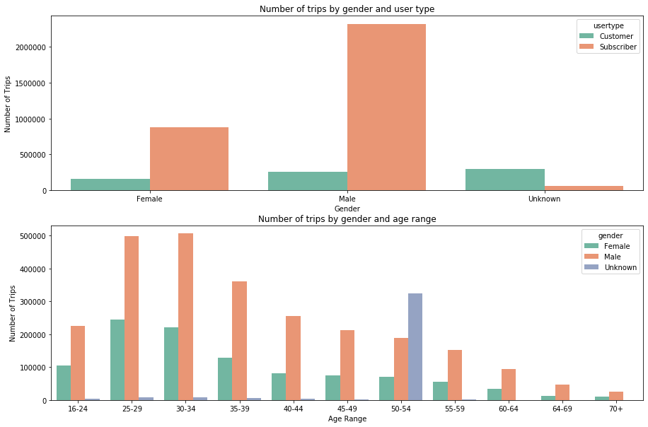

```python
plt.figure(figsize = [15, 10])

plt.subplot(2, 1, 1)
#count trips by gender and user type
trips_gender_usertype = durations_less_than_99_percentile.groupby(['usertype', 'gender'])['bikeid'].count()
trips_gender_usertype = trips_gender_usertype.reset_index(name='trips')
trips_gender_usertype

sb.barplot(data = trips_gender_usertype, x = 'gender', y = 'trips',  hue = 'usertype', palette = 'Set2')
plt.title('Number of trips by gender and user type')
plt.xlabel('Gender')
plt.ylabel('Number of Trips');

plt.subplot(2, 1, 2)
#count trips by age range and gender
trips_age_gender = durations_less_than_99_percentile.groupby(['gender', 'agerange'])['bikeid'].count()
trips_age_gender = trips_age_gender.reset_index(name='trips')
trips_age_gender

sb.barplot(data = trips_age_gender, x = 'agerange', y = 'trips',  hue = 'gender', palette = 'Set2')
plt.title('Number of trips by gender and age range')
plt.xlabel('Age Range')
plt.ylabel('Number of Trips');
```

## Number of Trips by Age Range and Gender and the Effect on Average Trip Duration 2/2

This shows that the group of interest - users aged between 50-54 with gender as 'Unknown' are the group with the highest average trip duration. Since this gender type is closely linked to customers, again this confirms that the user type is the strongest indicator of trip duration. The second group with a high average trip duration are riders with gender 'Female' and aged between 16 to 24.

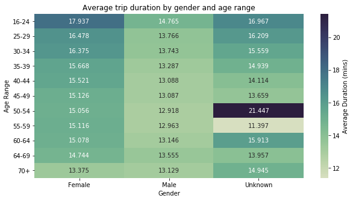

```python
# Average trip duration by age range and gender

average_duration_gender_age = durations_less_than_99_percentile.groupby(['gender', 'agerange'])['tripdurationmins'].mean()
average_duration_gender_age = average_duration_gender_age.reset_index(name='meandurationmins')
average_duration_gender_age = average_duration_gender_age.pivot(index = 'agerange', columns = 'gender', values = 'meandurationmins')
average_duration_gender_age

plt.figure(figsize = [10, 5])

sb.heatmap(average_duration_gender_age, annot = True, fmt = '.3f', cmap=heatmap_color,
           cbar_kws = {'label' : 'Average Duration (mins)'})
plt.title('Average trip duration by gender and age range')
plt.xlabel('Gender')
plt.ylabel('Age Range');
```

## Impact of COVID-19 on Number of Trips and Trip Duration

The next graph shows how in the beginning of 2020 the number of trips were higher in January and February than they were in 2019. However, those numbers fell in March 2020 compared to 2019 which marks the start of the first COVID-19 lockdown and continued to fall dramatically in April 2020. Number of trips continued to be less and looked to start to recover back to previous year's numbers by August. By September, 2020 numbers seem to have been higher which shows a recovery and continued to be higher than 2019 in the remaining months until the end of the year.

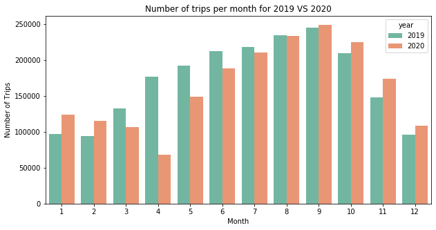

```python
#number of trips per month and year
plt.figure(figsize = [10, 5])
sb.countplot(data = df_main, x = 'month', hue = 'year', palette = 'Set2')
plt.title('Number of trips per month for 2019 VS 2020')
plt.xlabel('Month')
plt.ylabel('Number of Trips');
```

## One Final Interesting Insight!

Even though the number of trips between March and August 2020 was lower than the same months in 2019, this graph shows that the average duration of trips was actually higher. This could indicate that due to lockdown when shops, work, schools and other facilities were closed, people would have had more time to rent bikes to enjoy the outdoors in a socially distanced activity.

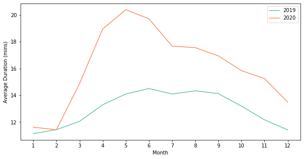

```python
#Average duration per month and year to show impact of COVID-19 on duration of trips

plt.figure(figsize = [10, 5])
average_duration_month_year = durations_less_than_99_percentile.groupby(['month', 'year'])['tripdurationmins'].mean()
average_duration_month_year = average_duration_month_year.reset_index(name='meandurationmins')
average_duration_month_year = average_duration_month_year.pivot(index = 'month', columns = 'year', values = 'meandurationmins')

plt.plot(average_duration_month_year[2019], label="2019", color = base_color)
plt.plot(average_duration_month_year[2020], label="2020", color = secondary_color)
plt.xticks(average_duration_month_year.index)
plt.ylabel('Average Duration (mins)')
plt.xlabel('Month')
plt.legend()
plt.show();
```